# Bank Marketing Report

Wojciech Piętak

## Introduction

The aim of this report is to analyze the following data set: https://archive.ics.uci.edu/ml/datasets/Bank+Marketing# with respect to dependencies between clients' characteristics, economic environment, and a fact of subscribing a term deposit by this client. In order to perform this exercise we will develop 3 classification models with a binary target variable stating whether a given client has subscribed a term deposit or not, evaluate their quality and provide analyses concerning impact of particular variables on target variable. Insight gained from this task conclusions may help develop marketing campaigns by optimizing clients targeting actions (and possibly their form), helping to choose clients that are most probable to subscribe a term deposit when targeted, thus decreasing advertising costs.

The data set consist of 41188 observations. There are 20 explanatory variables and a target variable. Explanatory variables concern client’s status, information about his bank loans, information related to the last contact with a client within current campaign and attributes regarding other campaigns, as well as some data concerning economic background, such as interest rates.

List of variables along with their description:

- bank client data:
1. age (numeric)
2. job: type of job (categorical: ‘admin.’,‘blue-collar’,‘entrepreneur’,‘housemaid’,‘management’,‘retired’,‘self-employed’,‘services’,‘student’,‘technician’,‘unemployed’,‘unknown’)
3. marital: marital status (categorical: ‘divorced’,‘married’,‘single’,‘unknown’; note: ‘divorced’ means divorced or widowed)
4. education (categorical: ‘basic.4y’,‘basic.6y’,‘basic.9y’,‘high.school’,‘illiterate’,‘professional.course’,‘university.degree’,‘unknown’)
5. default: has credit in default? (categorical: ‘no’,‘yes’,‘unknown’)
6. housing: has housing loan? (categorical: ‘no’,‘yes’,‘unknown’)
7. loan: has personal loan? (categorical: ‘no’,‘yes’,‘unknown’)
- related with the last contact of the current campaign:
8. contact: contact communication type (categorical: ‘cellular’,‘telephone’)
9. month: last contact month of year (categorical: ‘jan’, ‘feb’, ‘mar’, …, ‘nov’, ‘dec’)
10. day_of_week: last contact day of the week (categorical: ‘mon’,‘tue’,‘wed’,‘thu’,‘fri’)
11. duration: last contact duration, in seconds (numeric). Important note: this attribute highly affects the output target (e.g., if duration=0 then y=‘no’). Yet, the duration is not known before a call is performed. Also, after the end of the call y is obviously known. Thus, this input should only be included for benchmark purposes and should be discarded if the intention is to have a realistic predictive model.
- other attributes:
12. campaign: number of contacts performed during this campaign and for this client (numeric, includes last contact)
13. pdays: number of days that passed by after the client was last contacted from a previous campaign (numeric; 999 means client was not previously contacted)
14. previous: number of contacts performed before this campaign and for this client (numeric)
15. poutcome: outcome of the previous marketing campaign (categorical: ‘failure’,‘nonexistent’,‘success’) # social and economic context attributes
16. emp.var.rate: employment variation rate - quarterly indicator (numeric)
17. cons.price.idx: consumer price index - monthly indicator (numeric)
18. cons.conf.idx: consumer confidence index - monthly indicator (numeric)
19. euribor3m: euribor 3 month rate - daily indicator (numeric)
20. nr.employed: number of employees - quarterly indicator (numeric)
- output variable (desired target):
21. y - has the client subscribed a term deposit? (binary: ‘yes’,‘no’)

First, let’s load necessary libraries:

```r
library(dplyr)
library(ROCR)
library(corrplot)
library(mgcv)
#library(Ecdat)
#library(rpart)
#library(party)
library(randomForest)
library(car)
library(caret)
library(class)
library(pROC)
library(ggplot2)
#library(e1071)
#library(extraTrees)
#library(xgboost)
```

And read the data:

```r
DATA_SET <- read.csv2('bank-additional-full.csv')   # set the correct directory
head(DATA_SET)
```

|  | age | job | marital | education | default | housing | loan | contact | month | day_of_week | duration | campaign | pdays | previous | poutcome | emp.var.rate | cons.price.idx | cons.conf.idx | euribor3m | nr.employed | y |
| --- | --- | --- | --- | --- | --- | --- | --- | --- | --- | --- | --- | --- | --- | --- | --- | --- | --- | --- | --- | --- | --- |
| 1 | 56 | housemaid | married | basic.4y | no | no | no | telephone | may | mon | 261 | 1 | 999 | 0 | nonexistent | 01.sty | 93.994 | -36.4 | 4.857 | 5191 | no |
| 2 | 57 | services | married | high.school | unknown | no | no | telephone | may | mon | 149 | 1 | 999 | 0 | nonexistent | 01.sty | 93.994 | -36.4 | 4.857 | 5191 | no |
| 3 | 37 | services | married | high.school | no | yes | no | telephone | may | mon | 226 | 1 | 999 | 0 | nonexistent | 01.sty | 93.994 | -36.4 | 4.857 | 5191 | no |
| 4 | 40 | admin. | married | basic.6y | no | no | no | telephone | may | mon | 151 | 1 | 999 | 0 | nonexistent | 01.sty | 93.994 | -36.4 | 4.857 | 5191 | no |
| 5 | 56 | services | married | high.school | no | no | yes | telephone | may | mon | 307 | 1 | 999 | 0 | nonexistent | 01.sty | 93.994 | -36.4 | 4.857 | 5191 | no |
| 6 | 45 | services | married | basic.9y | unknown | no | no | telephone | may | mon | 198 | 1 | 999 | 0 | nonexistent | 01.sty | 93.994 | -36.4 | 4.857 | 5191 | no |

## Data cleaning and preprocessing

The data needs some preprocessing and cleaning in order to get binary variables instead of “yes”/“no” or factor variables and delete records with missing values.

Let’s check how many “unknowns” there are in each column:

```r
na <- data.frame(colname = colnames(DATA_SET), n = 0)
for (i in 1:21) {
  na$n[i] = sum(DATA_SET[,i] == "unknown")
}
na
```

| colname | n |
| --- | --- |
| age | 0 |
| job | 330 |
| marital | 80 |
| education | 1731 |
| default | 8597 |
| housing | 990 |
| loan | 990 |
| contact | 0 |
| month | 0 |
| day_of_week | 0 |

[output cut: 11 more lines]

We can delete records with unknown status of client’s job type, marital status and possession of housing or personal loan. However, there are too many records to be deleted due to the lack of data considering client’s education and credit default.

Let’s check values structure in these columns:

```r
table(DATA_SET$education)
```

```
##
##            basic.4y            basic.6y            basic.9y         high.school
##                4176                2292                6045                9515
##          illiterate professional.course   university.degree             unknown
##                  18                5243               12168                1731
```

```r
table(DATA_SET$default)
```

```
##
##      no unknown     yes
##   32588    8597       3
```

There are only 3 defaults in the whole data set. This column gives us virtually no information. We can drop it. Education is more problematic. We can see that “university.degree” is the most common value in this column. It is also the highest degree of education (which facilitates interpretation). We can create dummy variables for each category from this column and treat “university.degree” as a default value (we have to choose one in order to avoid collinearity). Observation with unknown education will be have assigned default category. We have to do the same for all categorical variables. Let’s start with the data related to clients and last contact. We will also drop column duration due to reason provided in the data description (as we want to build predictive models).

```r
DATA_SET <- DATA_SET[!(DATA_SET$job == 'unknown' | DATA_SET$marital == 'unknown' | DATA_SET$housing == 'unknown' | DATA_SET$loan == 'unknown'),]
DATA_SET <- DATA_SET[,!(colnames(DATA_SET) %in% c('default', 'duration'))]
table(DATA_SET$job)
```

```
##
##        admin.   blue-collar  entrepreneur     housemaid    management
##         10181          9001          1417          1028          2850
##       retired self-employed      services       student    technician
##          1671          1376          3862           851          6584
##    unemployed
##           982
```

```r
table(DATA_SET$marital)
```

```
##
## divorced  married   single
##     4478    24110    11215
```

```r
table(DATA_SET$contact)
```

```
##
##  cellular telephone
##     25369     14434
```

```r
for (i in unique(DATA_SET$job[DATA_SET$job != 'unemployed'])) {                 # set 'unemployed' as default
  DATA_SET$new = ifelse(DATA_SET$job == i, 1, 0)
  colnames(DATA_SET)[colnames(DATA_SET) == 'new'] = i
}
for (i in unique(DATA_SET$marital[DATA_SET$marital != 'single'])) {             # set 'single' as default
  DATA_SET$new = ifelse(DATA_SET$marital == i, 1, 0)
  colnames(DATA_SET)[colnames(DATA_SET) == 'new'] = i
}
for (i in unique(DATA_SET$education[!(DATA_SET$education %in% c('university.degree', 'unknown'))])) {
  DATA_SET$new = ifelse(DATA_SET$education == i, 1, 0)
  colnames(DATA_SET)[colnames(DATA_SET) == 'new'] = i
}
DATA_SET$housing = ifelse(DATA_SET$housing == 'yes', 1, 0)
DATA_SET$loan = ifelse(DATA_SET$loan == 'yes', 1, 0)
for (i in unique(DATA_SET$contact[DATA_SET$contact != 'cellular'])) {           # set 'cellular' as default
  DATA_SET$new = ifelse(DATA_SET$contact == i, 1, 0)
  colnames(DATA_SET)[colnames(DATA_SET) == 'new'] = i
}
for (i in unique(DATA_SET$month[DATA_SET$month != 'jan'])) {                    # set 'jan' as default
  DATA_SET$new = ifelse(DATA_SET$month == i, 1, 0)
  colnames(DATA_SET)[colnames(DATA_SET) == 'new'] = i
}
for (i in unique(DATA_SET$day_of_week[DATA_SET$day_of_week != 'mon'])) {        # set 'mon' as default
  DATA_SET$new = ifelse(DATA_SET$day_of_week == i, 1, 0)
  colnames(DATA_SET)[colnames(DATA_SET) == 'new'] = i
}
DATA_SET <- DATA_SET[,!(colnames(DATA_SET) %in% c('job', 'marital', 'education', 'contact', 'month', 'day_of_week'))]
```

Now we have to deal with data concerning previous contacts with client. The problematic issue that has to be addressed is that many clients were not contacted previously. For example number of days since the last contact from previous campaign (pdays) for such clients is set to 999. It completely distorts this variable. Let’s look closer on these variables structures:

```r
table(DATA_SET$campaign)
```

```
##
##     1     2     3     4     5     6     7     8     9    10    11    12    13
## 17040 10225  5159  2563  1558   947   607   385   268   214   175   119    86
##    14    15    16    17    18    19    20    21    22    23    24    25    26
##    66    47    48    56    31    25    30    22    17    16    15     8     8
##    27    28    29    30    31    32    33    34    35    37    39    40    41
##    11     8    10     7     7     4     4     3     5     1     1     2     1
##    42    43
##     2     2
```

```r
table(DATA_SET$pdays)
```

```
##
##     0     1     2     3     4     5     6     7     8     9    10    11    12
##    15    25    58   421   113    46   396    58    15    62    48    27    56
##    13    14    15    16    17    18    19    20    21    22    25    26    27
##    35    20    24    10     8     7     3     1     2     3     1     1     1
##   999
## 38347
```

```r
table(DATA_SET$previous)
```

```
##
##     0     1     2     3     4     5     6     7
## 34372  4412   722   207    66    18     5     1
```

```r
table(DATA_SET$poutcome)
```

```
##
##     failure nonexistent     success
##        4110       34372        1321
```

First important remark is that observations with pdays = 999 account for over 96% of all observations. Most of other values have at best few dozens of occurrences. Therefore, we can transform this variable into binary stating whether a client was contacted in the previous campaign or not. Second remark is that previous = 0 is the same as poutcome = ‘nonexistent’. Therefore, we will transform poutcome into binary stating whether there was a success in previous campaign. We will deal with campaign and previous in the next section.

```r
DATA_SET$prev_cont = ifelse(DATA_SET$pdays == 999, 0, 1)
DATA_SET$p_success = ifelse(DATA_SET$poutcome == "success", 1, 0)
DATA_SET <- DATA_SET[,!(colnames(DATA_SET) %in% c('pdays', 'poutcome'))]
```

We have to correct emp.var.rate and euribor3m variables, because Excel has transformed some values into dates, and change other macroeconomic variables into doubles:

```r
DATA_SET$emp.var.rate = as.double(ifelse(DATA_SET$emp.var.rate == "01.sty", 1.1, ifelse(DATA_SET$emp.var.rate == "01.kwi", 1.4, DATA_SET$emp.var.rate)))
DATA_SET$cons.price.idx = as.double(DATA_SET$cons.price.idx)
DATA_SET$cons.conf.idx = as.double(DATA_SET$cons.conf.idx)
DATA_SET$euribor3m = as.double(gsub("sty", "01", gsub("mar", "03", gsub("kwi", "04", gsub("maj", "05", gsub("lip", "07", gsub("gru", "12", DATA_SET$euribor3m)))))))
DATA_SET$nr.employed = as.double(DATA_SET$nr.employed)
```

Transform the target into binary:

```r
DATA_SET$y = ifelse(DATA_SET$y == "yes", 1, 0)
```

## EDA

In the next step we will analyze the data in descriptive terms (including plots) and in terms of correlations between variables. In particular, we want to gain some insight on how does target variable depend on other variables. First, let’s define some useful functions:

```r
#Function to draw histograms and density estimates
DoHistogram = function(values, values.name) {
  histogram = hist(values, plot = FALSE)
  density.estimate = density(values)
  y.maximum = max(histogram$density, density.estimate$y)
  plot(histogram, freq = FALSE, ylim = c(0, y.maximum),
       xlab = values.name, ylab = "density", main = NULL)
  lines(density.estimate, lwd = 2)
}
#Function to draw scatterplots and splines
DoScatterplot = function(x.values, x.name) {
  plot(x.values, DATA_SET$y,
       xlab = x.name, ylab = "y", main = NULL, col = gray(0.4))
  lines(smooth.spline(x.values, DATA_SET$MORT), lwd = 2)
  abline(lm(DATA_SET$y ~ x.values)$coef, col = gray(0.7), lwd = 2, lty = 2)
}
#Function to obtain p-values of the correlations
cor.mtest = function(mat, ...) {
  mat = as.matrix(mat)
  n = ncol(mat)
  p.mat= matrix(NA, n, n)
  diag(p.mat) = 0
  for (i in 1:(n - 1)) {
    for (j in (i + 1):n) {
      tmp = cor.test(mat[, i], mat[, j], ...)
      p.mat[i, j] = p.mat[j, i] = tmp$p.value
    }
  }
  colnames(p.mat) = rownames(p.mat) = colnames(mat)
  p.mat
}
#Function to create barplots with impact on target variable
plotBarplot = function(x,x_nms){
  barplot(tapply(DATA_SET$y,x,mean), ylab="y",names.arg=c(0,1),xlab=x_nms,ylim=c(0,1))
}
```

And take a look on desriptive statistics and basic correlations:

```r
print(summary(DATA_SET))
```

```
##       age           housing           loan           campaign
##  Min.   :17.00   Min.   :0.000   Min.   :0.0000   Min.   : 1.000
##  1st Qu.:32.00   1st Qu.:0.000   1st Qu.:0.0000   1st Qu.: 1.000
##  Median :38.00   Median :1.000   Median :0.0000   Median : 2.000
##  Mean   :39.98   Mean   :0.537   Mean   :0.1553   Mean   : 2.566
##  3rd Qu.:47.00   3rd Qu.:1.000   3rd Qu.:0.0000   3rd Qu.: 3.000
##  Max.   :98.00   Max.   :1.000   Max.   :1.0000   Max.   :43.000
##     previous       emp.var.rate      cons.price.idx  cons.conf.idx
##  Min.   :0.0000   Min.   :-3.40000   Min.   :92.20   Min.   :-50.80
##  1st Qu.:0.0000   1st Qu.:-1.80000   1st Qu.:93.08   1st Qu.:-42.70
##  Median :0.0000   Median : 1.10000   Median :93.75   Median :-41.80
##  Mean   :0.1726   Mean   : 0.07978   Mean   :93.57   Mean   :-40.52
##  3rd Qu.:0.0000   3rd Qu.: 1.40000   3rd Qu.:93.99   3rd Qu.:-36.40
##  Max.   :7.0000   Max.   : 1.40000   Max.   :94.77   Max.   :-26.90
##    euribor3m      nr.employed         y            housemaid
##  Min.   :0.634   Min.   :4964   Min.   :0.0000   Min.   :0.00000
##  1st Qu.:1.344   1st Qu.:5099   1st Qu.:0.0000   1st Qu.:0.00000
##  Median :4.857   Median :5191   Median :0.0000   Median :0.00000
##  Mean   :3.619   Mean   :5167   Mean   :0.1127   Mean   :0.02583
##  3rd Qu.:4.961   3rd Qu.:5228   3rd Qu.:0.0000   3rd Qu.:0.00000
##  Max.   :5.045   Max.   :5228   Max.   :1.0000   Max.   :1.00000
##     services           admin.        blue-collar       technician
##  Min.   :0.00000   Min.   :0.0000   Min.   :0.0000   Min.   :0.0000
##  1st Qu.:0.00000   1st Qu.:0.0000   1st Qu.:0.0000   1st Qu.:0.0000
##  Median :0.00000   Median :0.0000   Median :0.0000   Median :0.0000
##  Mean   :0.09703   Mean   :0.2558   Mean   :0.2261   Mean   :0.1654
##  3rd Qu.:0.00000   3rd Qu.:1.0000   3rd Qu.:0.0000   3rd Qu.:0.0000
##  Max.   :1.00000   Max.   :1.0000   Max.   :1.0000   Max.   :1.0000
##     retired          management     self-employed      entrepreneur
##  Min.   :0.00000   Min.   :0.0000   Min.   :0.00000   Min.   :0.0000
##  1st Qu.:0.00000   1st Qu.:0.0000   1st Qu.:0.00000   1st Qu.:0.0000
##  Median :0.00000   Median :0.0000   Median :0.00000   Median :0.0000
##  Mean   :0.04198   Mean   :0.0716   Mean   :0.03457   Mean   :0.0356
##  3rd Qu.:0.00000   3rd Qu.:0.0000   3rd Qu.:0.00000   3rd Qu.:0.0000
##  Max.   :1.00000   Max.   :1.0000   Max.   :1.00000   Max.   :1.0000
##     student           married          divorced         basic.4y
##  Min.   :0.00000   Min.   :0.0000   Min.   :0.0000   Min.   :0.0000
##  1st Qu.:0.00000   1st Qu.:0.0000   1st Qu.:0.0000   1st Qu.:0.0000
##  Median :0.00000   Median :1.0000   Median :0.0000   Median :0.0000
##  Mean   :0.02138   Mean   :0.6057   Mean   :0.1125   Mean   :0.1005
```

[output cut: 29 more lines]

```
##  Max.   :1.000000   Max.   :1.00000   Max.   :1.00000   Max.   :1.00000
##       tue              wed              thu              fri
##  Min.   :0.0000   Min.   :0.0000   Min.   :0.0000   Min.   :0.0000
##  1st Qu.:0.0000   1st Qu.:0.0000   1st Qu.:0.0000   1st Qu.:0.0000
##  Median :0.0000   Median :0.0000   Median :0.0000   Median :0.0000
##  Mean   :0.1959   Mean   :0.1974   Mean   :0.2096   Mean   :0.1904
##  3rd Qu.:0.0000   3rd Qu.:0.0000   3rd Qu.:0.0000   3rd Qu.:0.0000
##  Max.   :1.0000   Max.   :1.0000   Max.   :1.0000   Max.   :1.0000
##    prev_cont         p_success
##  Min.   :0.00000   Min.   :0.00000
##  1st Qu.:0.00000   1st Qu.:0.00000
##  Median :0.00000   Median :0.00000
##  Mean   :0.03658   Mean   :0.03319
##  3rd Qu.:0.00000   3rd Qu.:0.00000
##  Max.   :1.00000   Max.   :1.00000
```

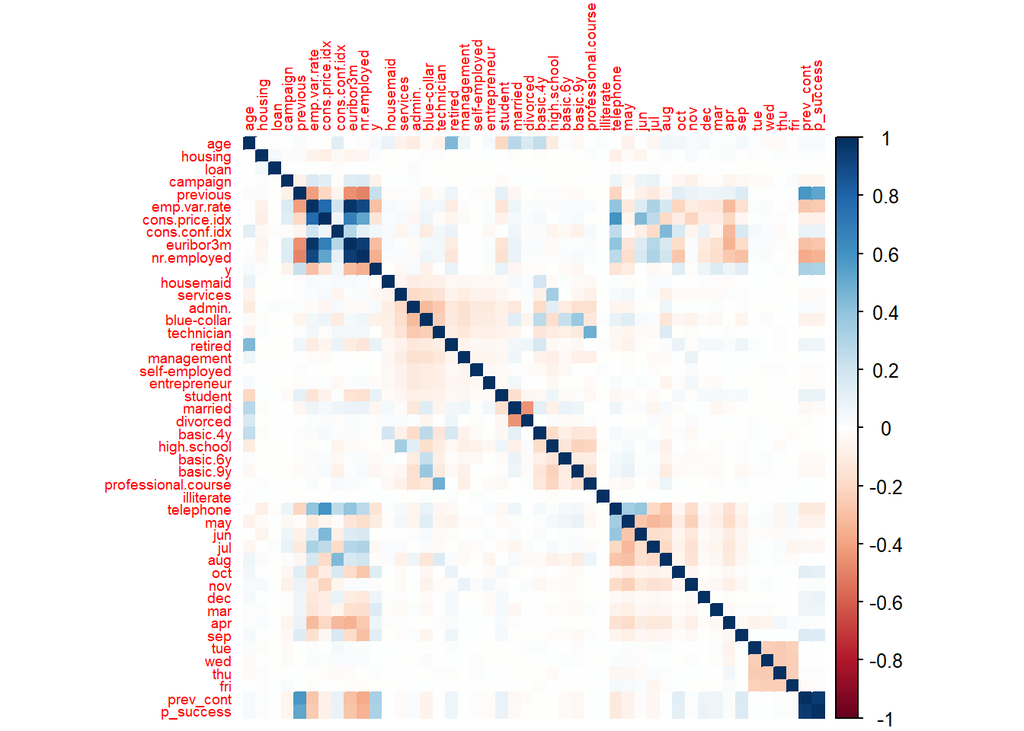

```r
cormat = cor(DATA_SET)
par(mfrow = c(1,1))
corrplot(cormat, method="color", tl.cex = 0.6)
```

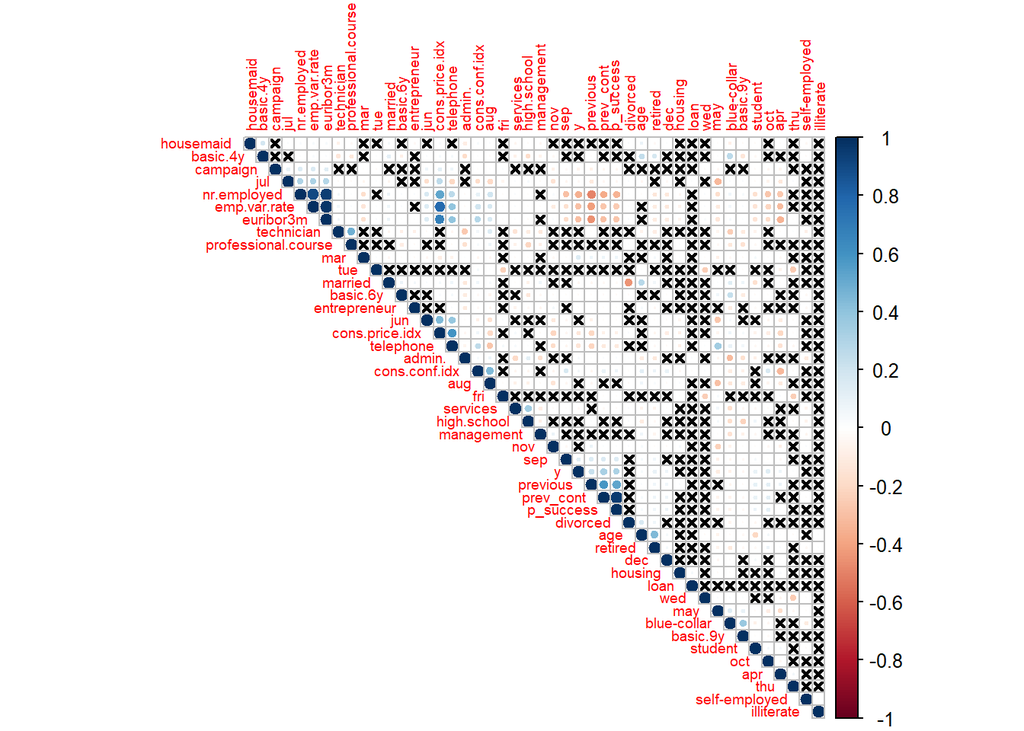

```r
p.mat = cor.mtest(DATA_SET)
corrplot(cormat, type="upper", order="hclust", tl.cex = 0.6, pch.cex = 0.7, p.mat = p.mat, sig.level = 0.01)    # It works when ran through Knit, otherwise must be p.mat$p instead of p.mat (however p.mat$p does not work for Knit)
```

Most of the variables are binary. Some of them are quite well balanced (e.g. days), but for some positive value accounts for only few percents (e.g. some months, prev_cont, p_success). Values of campaign and previous variables have very asymmetric distribution.

In terms of correlation, there are not many strong statistical dependencies. High correlation is visible mainly between macroeconomic variables, between macroeconomic and monthly variables (seasonality), between education and job and there is of course negative dependence between binary variables that exclude each other. Target variable is completely uncorrelated with over 1/3 of variables; there is a visible correlation with some macroeconomic variables and variables related to previous contacts/campaigns.

Willingness to subscribe a deposit is negatively correlated with interest rates on the interbank market and situation on labor market (number of employees and its volatility). Those 3 macroeconomic variables are strongly correlated with each other. At the peak of economic boom, employment is still very high, but people start to worry about the future. They increase demand for money (liquid assets), because they expect prices to fall, supply of real command of capital (financial capital/savings) decreases, which increases its price (interests). Therefore, they are not willing to subscribe a term deposit with frozen means, because they need liquid assets, so they prefer deposits on demand. Simultaneously companies increase demand for command of capital, as they seek for liquidity, which also increases short-term interests rates. But then comes the bust - demand for labor decreases, employers decrease job places, unemployment increases, which decreases number of employees and employment variation. Also, central bank’s intervention comes in place - it triggers fiduciary expansion, increasing the supply of command of capital without real savings, by providing banks with created money, thus decreasing interest rates. At the time, markets clear up from malinvestments and unemployment increases (number of employees decreases). Then people expect situation to improve and are more willing to save and invest (rather than increase cash balances). Hence, term deposit subscriptions rise.

However, macroeconomic situation is not what bank has impact on. It can give some insight on when to increase or decrease advertising or run intensive marketing campaigns, but gives no information about which clients to choose. There comes information from previous campaigns - it turns out that people contacted in previous campaigns, especially those contacted many times in previous campaigns and those contact with whom ended up with a success are more willing to subscribe a term deposit. But this may be due to the fact that the bank have already picked people with higher probability of success when targeted.

Now, let’s deal with campaign and previous variables.

```r
prev_y_0 <- DATA_SET[,colnames(DATA_SET) %in% c('previous', 'y')] %>%
   group_by(previous) %>%
   summarize(y_0 = sum(y == 0), y_1 = sum(y == 1), ratio = sum(y == 1) / sum(y == 0)) %>%
   select(previous, y_0, y_1, ratio)
prev_y_0
```

| previous | y_0 | y_1 | ratio |
| --- | --- | --- | --- |
| 0 | 31321 | 3051 | 0.09741068 |
| 1 | 3482 | 930 | 0.26708788 |
| 2 | 392 | 330 | 0.84183673 |
| 3 | 83 | 124 | 1.49397590 |
| 4 | 30 | 36 | 1.20000000 |
| 5 | 5 | 13 | 2.60000000 |
| 6 | 2 | 3 | 1.50000000 |
| 7 | 1 | 0 | 0.00000000 |

```r
camp_y_0 <- DATA_SET[,colnames(DATA_SET) %in% c('campaign', 'y')] %>%
   group_by(campaign) %>%
   summarize(y_0 = sum(y == 0), y_1 = sum(y == 1), ratio = sum(y == 1) / sum(y == 0)) %>%
   select(campaign, y_0, y_1, ratio)
camp_y_0
```

| campaign | y_0 | y_1 | ratio |
| --- | --- | --- | --- |
| 1 | 14830 | 2210 | 0.14902225 |
| 2 | 9048 | 1177 | 0.13008400 |
| 3 | 4601 | 558 | 0.12127798 |
| 4 | 2318 | 245 | 0.10569456 |
| 5 | 1440 | 118 | 0.08194444 |
| 6 | 874 | 73 | 0.08352403 |
| 7 | 570 | 37 | 0.06491228 |
| 8 | 369 | 16 | 0.04336043 |
| 9 | 251 | 17 | 0.06772908 |
| 10 | 204 | 10 | 0.04901961 |

[output cut: 31 more lines]

We can observe that values of those variables are very unbalanced. Lower values are very frequent and higher - not. Also, in both cases there is a visible trend in target variable values proportion, at least to some point - for values above given threshold the trend disappears (especially in case of campaign) and numbers of observations decrease very quickly. It seems reasonable to merge those higher values with very few observations and no trend in target variable, thus creating intervals and transforming variables into categorical in order to create dummies. Interestingly, mentioned trends have opposite direction - the number of contacts in previous campaigns increases probability of success, but the number of contacts in a current campaign decreases it.

```r
prev_y <- DATA_SET[,colnames(DATA_SET) %in% c('previous', 'y')] %>%
  mutate(g_prev = ifelse(previous == 0, '0', ifelse(previous == 1, '1', ifelse(previous == 2, '2', '3+')))) %>%
  group_by(g_prev) %>%
  summarize(y_0 = sum(y == 0), y_1 = sum(y == 1), ratio = sum(y == 1) / sum(y == 0)) %>%
  select(g_prev, y_0, y_1, ratio)
prev_y
```

| g_prev | y_0 | y_1 | ratio |
| --- | --- | --- | --- |
| 0 | 31321 | 3051 | 0.09741068 |
| 1 | 3482 | 930 | 0.26708788 |
| 2 | 392 | 330 | 0.84183673 |
| 3+ | 121 | 176 | 1.45454545 |

```r
camp_y <- DATA_SET[,colnames(DATA_SET) %in% c('campaign', 'y')] %>%
  mutate(g_camp = ifelse(campaign == 1, '1', ifelse(campaign <= 3, '2-3', ifelse(campaign <= 6, '4-6', '7+')))) %>%
  group_by(g_camp) %>%
  summarize(y_0 = sum(y == 0), y_1 = sum(y == 1), ratio = sum(y == 1) / sum(y == 0)) %>%
  select(g_camp, y_0, y_1, ratio)
camp_y
```

| g_camp | y_0 | y_1 | ratio |
| --- | --- | --- | --- |
| 1 | 14830 | 2210 | 0.14902225 |
| 2-3 | 13649 | 1735 | 0.12711554 |
| 4-6 | 4632 | 436 | 0.09412781 |
| 7+ | 2205 | 106 | 0.04807256 |

Data appears to be more balanced now, trend is clearly visible and each category has some substantial number of observations. We can create dummies now:

```r
DATA_SET$previous = ifelse(DATA_SET$previous == 0, 'prev_0', ifelse(DATA_SET$previous == 1, 'prev_1', ifelse(DATA_SET$previous == 2, 'prev_2', 'prev_3_')))
DATA_SET$campaign = ifelse(DATA_SET$campaign == 1, 'camp_1', ifelse(DATA_SET$campaign <= 3, 'camp_2-3', ifelse(DATA_SET$campaign <= 6, 'camp_4-6', 'camp_7_')))
for (i in unique(DATA_SET$previous[DATA_SET$previous != 'prev_0'])) {           # set 0 as default
  DATA_SET$new = ifelse(DATA_SET$previous == i, 1, 0)
  colnames(DATA_SET)[colnames(DATA_SET) == 'new'] = i
}
for (i in unique(DATA_SET$campaign[DATA_SET$campaign != 'camp_1'])) {           # set 1 as default
  DATA_SET$new = ifelse(DATA_SET$campaign == i, 1, 0)
  colnames(DATA_SET)[colnames(DATA_SET) == 'new'] = i
}
DATA_SET <- DATA_SET[,!(colnames(DATA_SET) %in% c('previous', 'campaign'))]
colnames(DATA_SET) <- gsub("-", "_", colnames(DATA_SET))
```

Almost all of variables in the dataset (except for age and macroeconomic variables) are binary. In the next step we will assess for which of them positive value may increase or decrease probability of positive value of the target variable. In order to do so, we will create bar plots with average value of the target variable, depending on value of each binary variable.

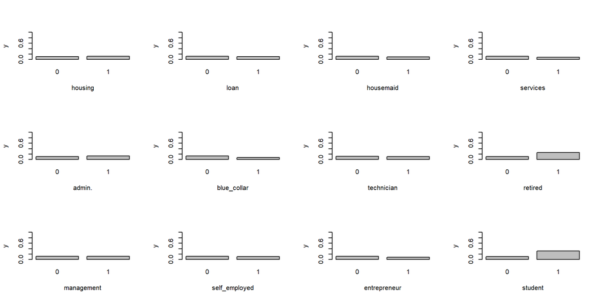

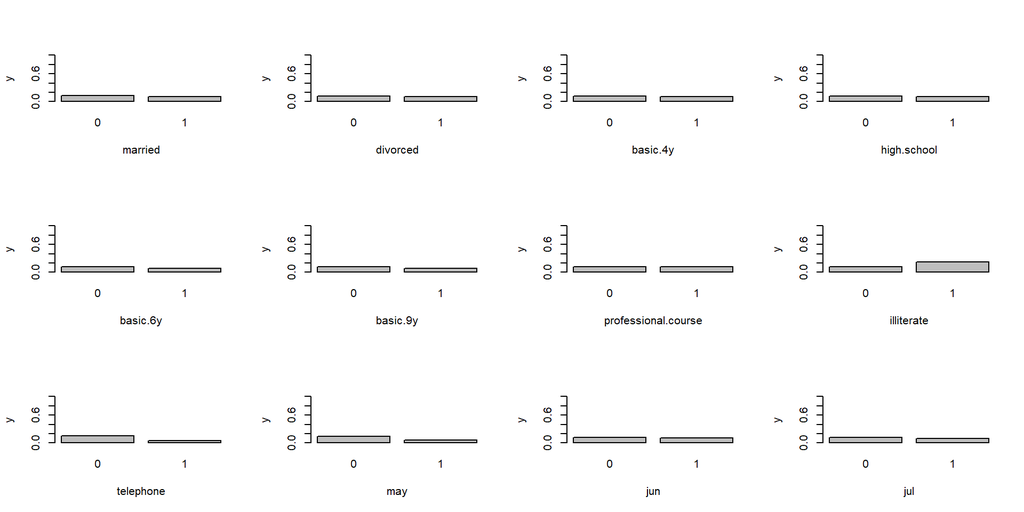

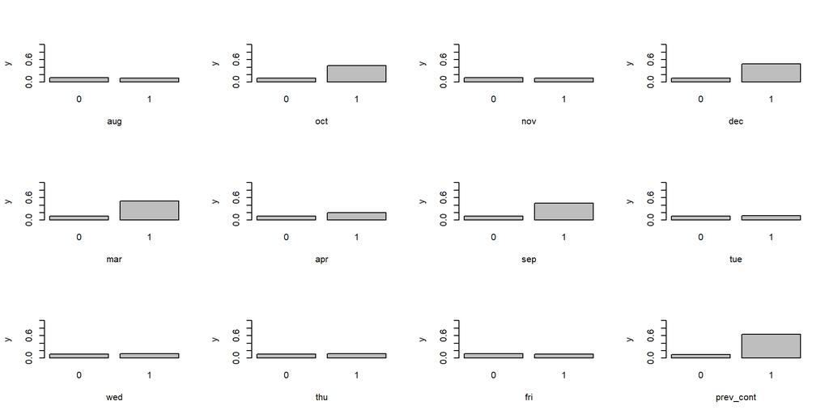

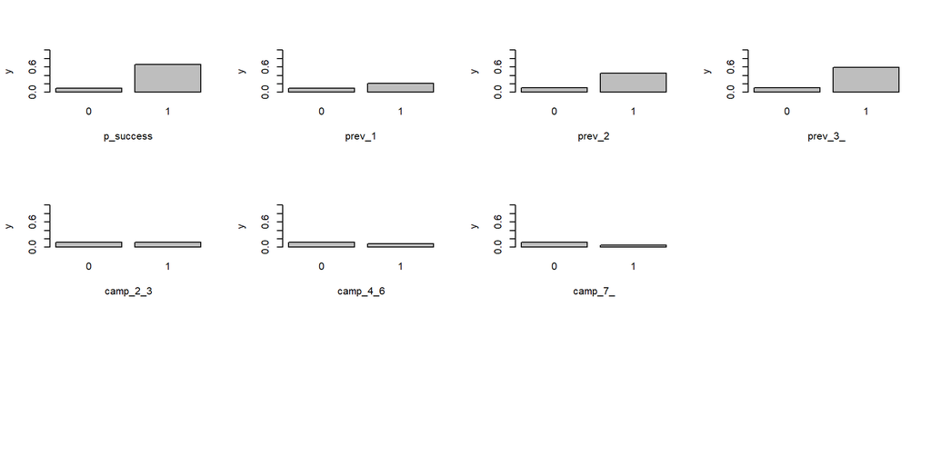

```r
par(mfrow=c(3,4))
invisible(mapply(plotBarplot, x=DATA_SET[,!(colnames(DATA_SET) %in% c('age', 'emp.var.rate', 'cons.price.idx', 'cons.conf.idx', 'euribor3m', 'nr.employed', 'y'))], x_nms=colnames(DATA_SET)[!(colnames(DATA_SET) %in% c('age', 'emp.var.rate', 'cons.price.idx', 'cons.conf.idx', 'euribor3m', 'nr.employed', 'y'))]))
```

We can see that probability of positive response of the potential customer is higher if he is retired, if he is a student or if he is illiterate. It is lower if he is called on telephone or if he is called in May. Probability of success grows substantially if he is called in October, December, March or September. Clients contacted in previous campaigns are more likely to accept the offer, especially if it ended up with a success or they were contacted 2 or more times.

The last step concerning EDA is clustering. We will use K-Means Clustering applied to 4 categories of variables (type of client, information about given contact, information concerning previous contacts and campaigns and macroeconomic variables) to explore some categories of clients or circumstances under which probability of term deposit subscription is substantially higher. In order to choose the number of groups we will use the “elbow rule” to see if there is a threshold after which within-cluster sum of squares stops to drop substantially with further divisions. Let’s start with macroeconomic variables

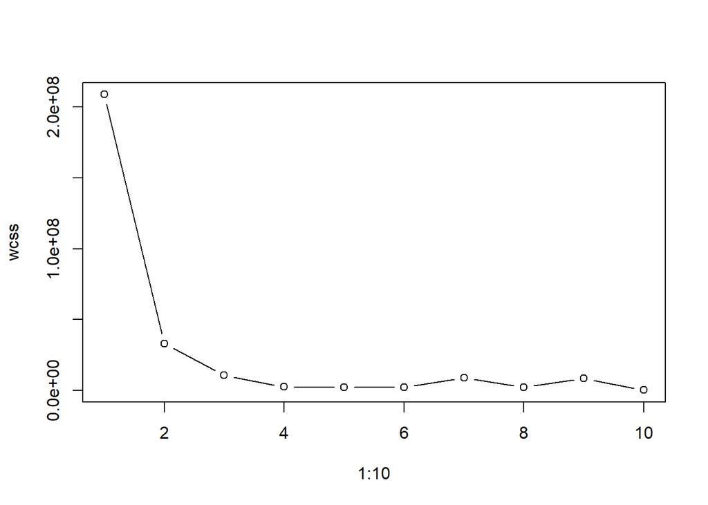

```r
set.seed(123)
wcss <- vector()
for (i in 1:10) wcss[i] = sum(kmeans(DATA_SET[,c('euribor3m','cons.price.idx', 'nr.employed', 'emp.var.rate', 'cons.conf.idx', 'y')], i)$withinss)
plot(1:10, wcss, type = "b")
```

```r
set.seed(123)
kmeans(DATA_SET[,c('euribor3m','cons.price.idx', 'nr.employed', 'emp.var.rate', 'cons.conf.idx', 'y')], 2)$centers
```

```
##   euribor3m cons.price.idx nr.employed emp.var.rate cons.conf.idx          y
## 1  4.815608       93.83982    5213.408     1.113730     -39.47250 0.04869474
## 2  1.168763       93.02788    5072.128    -2.036219     -42.66687 0.24378109
```

It is quite clear that - as described before - there is a strong willingness to subscribe a term deposit in the phase of business cycle when interest rates have been already decreased by the central bank, prices may have dropped a little bit (but the effect of increased demand for money on prices was reduced by central bank intervention), unemployment is high and situation is pretty bad in general. On the other hand, at the very peak of the boom, just before the collapse, when the yield curve happens to reverse, the willingness to subscribe a term deposit is very low.

Next, let’s focus on clients types categories, including job, education, age etc.

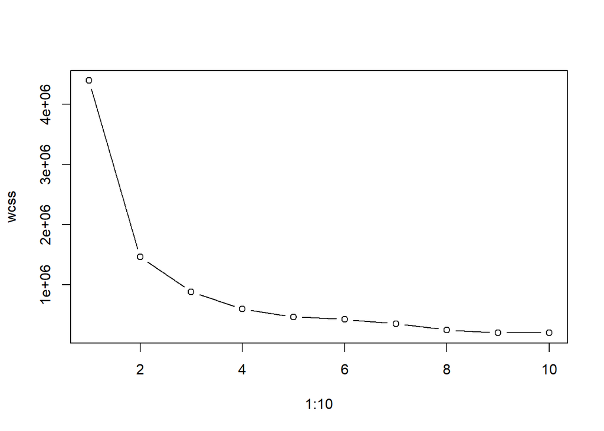

```r
set.seed(34)
wcss <- vector()
for (i in 1:10) wcss[i] = sum(kmeans(DATA_SET[,c(1:3, 9:27)], i)$withinss)
plot(1:10, wcss, type = "b")
```

```r
set.seed(34)
kmeans(DATA_SET[,c(1:3, 9:27)], 2)$centers
```

```
##        age   housing      loan         y  housemaid   services    admin.
## 1 33.11980 0.5382050 0.1562783 0.1132153 0.01704405 0.10576369 0.2848086
## 2 50.72217 0.5352285 0.1538709 0.1119706 0.03957971 0.08334945 0.2103397
##   blue_collar technician     retired management self_employed entrepreneur
## 1   0.2242898  0.1844380 0.001523261 0.05825443    0.03408810   0.03079457
## 2   0.2290337  0.1356282 0.105331013 0.09250306    0.03532521   0.04312512
##        student   married   divorced   basic.4y high.school   basic.6y  basic.9y
## 1 0.0348703170 0.5187320 0.07686291 0.05154385   0.2580486 0.05327295 0.1520379
## 2 0.0002578483 0.7419584 0.16831045 0.17727068   0.1918391 0.05866048 0.1394314
##   professional.course   illiterate
## 1           0.1297242 0.0001235076
## 2           0.1256366 0.0009669310
```

```r
kmeans(DATA_SET[,c(1:3, 9:27)], 7)$centers
```

```
##        age   housing      loan          y   housemaid    services     admin.
## 1 40.33113 0.5269040 0.1432119 0.08443709 0.029249448 0.092439294 0.24489514
## 2 35.44429 0.5375951 0.1656012 0.09573820 0.018417047 0.093911720 0.28477930
## 3 25.68219 0.5417790 0.1555991 0.17299681 0.007841215 0.136241117 0.25630973
## 4 31.09494 0.5427767 0.1579627 0.11430583 0.012674569 0.108672691 0.32320150
## 5 74.04724 0.5559055 0.1480315 0.46771654 0.056692913 0.001574803 0.02677165
## 6 47.27072 0.5343754 0.1582515 0.08272237 0.033752940 0.099183843 0.23225896
## 7 55.74108 0.5386845 0.1518391 0.12158000 0.049827867 0.067947092 0.18825874
##   blue_collar technician      retired management self_employed entrepreneur
## 1 0.262003311 0.17563466 0.0041390728 0.08264349   0.036975717  0.043322296
## 2 0.235768645 0.19649924 0.0022831050 0.06818874   0.032572298  0.036377473
## 3 0.216858613 0.12545945 0.0004900760 0.02793433   0.032590051  0.015682431
## 4 0.195986387 0.20373196 0.0007041427 0.05410163   0.034268278  0.026405351
## 5 0.007874016 0.01102362 0.8582677165 0.02204724   0.004724409  0.006299213
## 6 0.276940102 0.14580163 0.0121731913 0.08839397   0.034167935  0.047032785
```

[output cut: 17 more lines]

Elbow rule indicates k = 2 as optimal number of clusters, but there is nothing interesting actually in such clustering. Let’s look at k = 7 results. We can see that there is one group with particularly high probability of term deposit subscription - old, probably retired, rather married and not necessarily well-educated people. The second group with slightly higher probability of success are quite young people, maybe just after studies, starting to earn money on they own.

Now, let’s take a look on data concerning characteristics of a given contact:

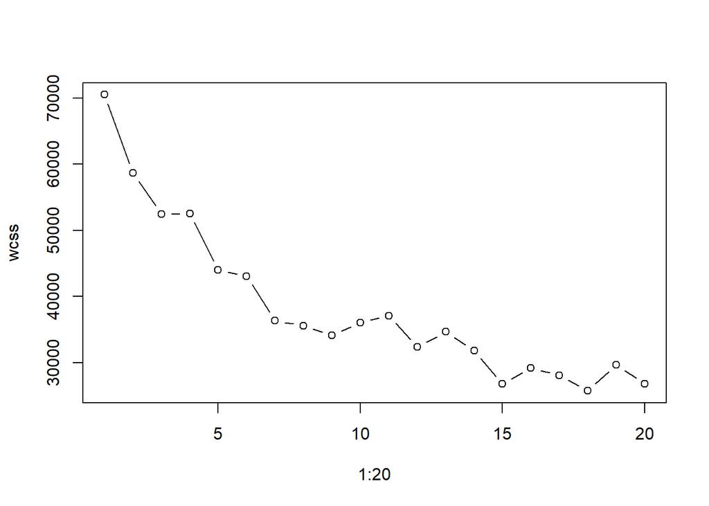

```r
set.seed(30)
wcss <- vector()
for (i in 1:20) wcss[i] = sum(kmeans(DATA_SET[,c(9,28:42)], i)$withinss)
plot(1:20, wcss, type = "b")
```

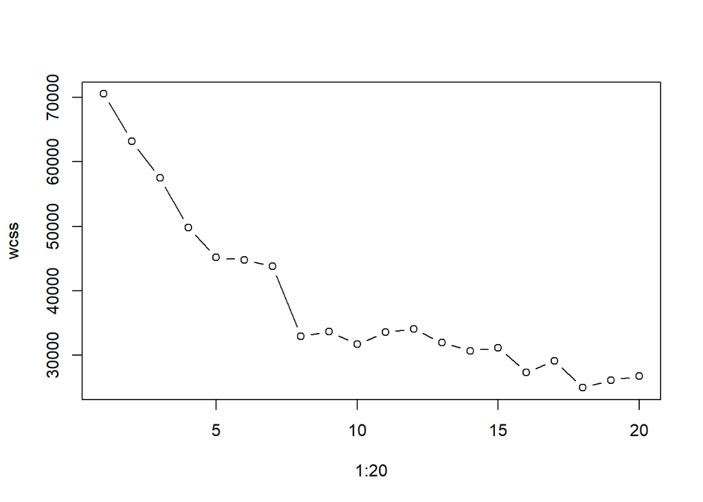

```r
set.seed(155)
wcss <- vector()
for (i in 1:20) wcss[i] = sum(kmeans(DATA_SET[,c(9,28:42)], i)$withinss)
plot(1:20, wcss, type = "b")
```

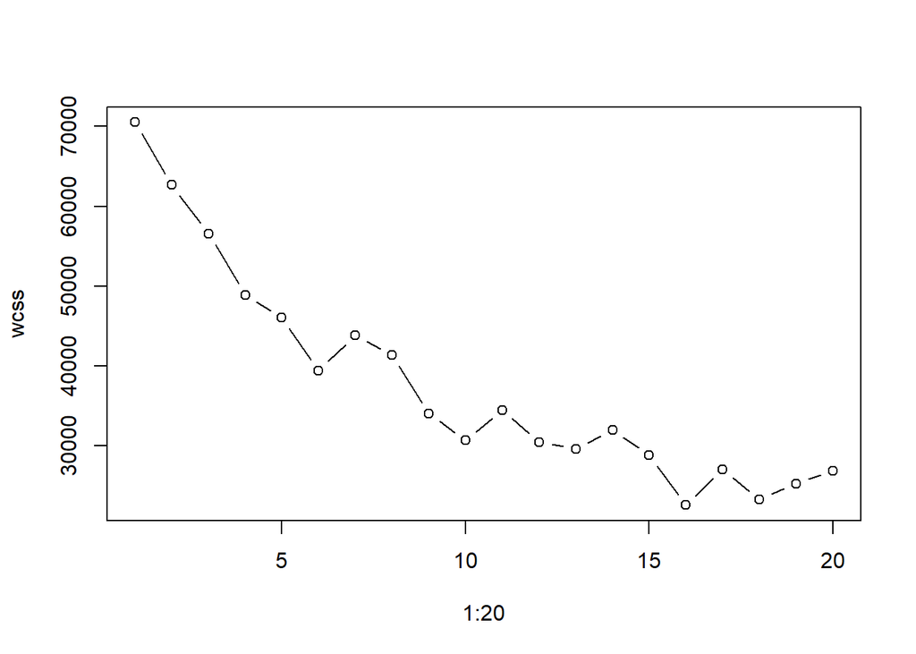

```r
set.seed(72)
wcss <- vector()
for (i in 1:20) wcss[i] = sum(kmeans(DATA_SET[,c(9,28:42)], i)$withinss)
plot(1:20, wcss, type = "b")
```

```r
set.seed(30)
kmeans(DATA_SET[,c(9,28:42)], 11)$centers
```

```
##             y  telephone       may        jun       jul        aug        oct
## 1  0.05465247 0.61266816 1.0000000 0.00000000 0.0000000 0.00000000 0.00000000
## 2  0.34093229 0.05988431 0.0000000 0.00000000 0.0000000 0.00000000 0.11432460
## 3  0.10323710 0.92475941 0.0000000 0.79965004 0.0000000 0.04724409 0.02012248
## 4  0.15504265 0.14049172 0.0000000 0.00000000 0.8173608 0.00000000 0.06723532
## 5  0.09750297 0.86040428 0.0000000 0.96385256 0.0000000 0.00000000 0.01403092
## 6  0.10117227 0.08282365 0.0000000 0.00000000 0.0000000 0.00000000 0.00000000
## 7  0.33559322 0.07711864 0.1033898 0.08728814 0.0000000 0.00000000 0.11440678
## 8  0.06413399 0.55228758 1.0000000 0.00000000 0.0000000 0.00000000 0.00000000
## 9  0.11337209 0.05620155 0.0000000 0.00000000 0.0000000 1.00000000 0.00000000
## 10 0.10300429 0.02983854 0.0000000 0.00000000 0.0000000 1.00000000 0.00000000
## 11 0.09210034 0.14470236 0.0000000 0.00000000 1.0000000 0.00000000 0.00000000
##           nov         dec         mar        apr        sep       tue       wed
## 1  0.00000000 0.000000000 0.000000000 0.00000000 0.00000000 0.2516816 0.2639200
## 2  0.00000000 0.031303164 0.107519564 0.65634570 0.09050698 0.2085743 0.2027901
```

[output cut: 21 more lines]

```r
kmeans(DATA_SET[,c(9,28:42)], 11)$size
```

```
##  [1] 4071 5342 3847 5698  521 8059 1349 4196 1282 2511 2927
```

```r
kmeans(DATA_SET[,c(9,28:42)], 19)$centers
```

```
##             y  telephone       may        jun jul        aug         oct
## 1  0.16145455 0.76945455 0.0000000 0.98109091   0 0.00000000 0.000000000
## 2  0.06439262 0.60111382 0.9832927 0.00000000   0 0.00000000 0.000000000
## 3  0.04535865 0.91455696 0.0000000 0.91244726   0 0.03797468 0.000000000
## 4  0.45117188 0.20898438 0.0000000 0.00000000   0 0.00000000 1.000000000
## 5  0.09805209 0.00000000 0.0000000 0.00000000   1 0.00000000 0.000000000
## 6  0.04642857 1.00000000 0.0000000 0.00000000   1 0.00000000 0.000000000
## 7  1.00000000 0.06945766 0.0000000 0.06565176   0 0.13415794 0.000000000
## 8  0.02961433 0.97589532 0.5805785 0.32610193   0 0.01997245 0.006198347
## 9  0.00000000 0.04375304 0.0000000 0.00000000   0 0.00000000 0.000000000
## 10 0.09266123 0.00000000 0.0000000 0.00000000   1 0.00000000 0.000000000
## 11 0.05288111 0.62691466 0.9824945 0.00000000   0 0.00000000 0.000000000
## 12 0.05692109 1.00000000 0.0000000 0.00000000   1 0.00000000 0.000000000
## 13 0.09977102 0.08112529 0.0000000 0.00000000   0 0.00000000 0.000000000
## 14 0.45222930 0.14649682 0.0000000 0.00000000   0 0.00000000 1.000000000
```

[output cut: 45 more lines]

```r
set.seed(155)
kmeans(DATA_SET[,c(9,28:42)], 11)$centers
```

```
##             y  telephone       may         jun        jul       aug         oct
## 1  0.19268667 0.06349901 0.0000000 0.009415371 0.00000000 0.0000000 0.053207795
## 2  0.10329493 0.04042854 0.0000000 0.000000000 0.00000000 1.0000000 0.000000000
## 3  0.37070151 0.03988996 0.0000000 0.030949106 0.07221458 0.7097662 0.037138927
## 4  0.05163102 0.43378700 0.5977533 0.012529704 0.19032188 0.0000000 0.017498380
## 5  0.19148936 0.12797714 0.0000000 0.070816132 0.46872023 0.0000000 0.045093681
## 6  0.06116373 0.51231394 0.7645467 0.000000000 0.00000000 0.0000000 0.007577808
## 7  0.06714162 0.94451641 0.0000000 0.982512953 0.00000000 0.0000000 0.006044905
## 8  0.22622780 0.11755486 0.0000000 0.078369906 0.73510972 0.0000000 0.052246604
## 9  0.05382331 0.63808463 1.0000000 0.000000000 0.00000000 0.0000000 0.000000000
## 10 0.08252740 0.14603482 0.0000000 0.000000000 1.00000000 0.0000000 0.000000000
## 11 0.06852590 0.55976096 0.9936255 0.000000000 0.00000000 0.0000000 0.002191235
##           nov          dec         mar         apr         sep       tue
## 1  0.35581344 0.0175169696 0.045106197 0.481278739 0.037661485 0.0000000
## 2  0.00000000 0.0000000000 0.000000000 0.000000000 0.000000000 0.2528805
```

[output cut: 21 more lines]

```r
set.seed(72)
kmeans(DATA_SET[,c(9,28:42)], 11)$centers
```

```
##             y   telephone       may        jun        jul         aug
## 1  0.00000000 0.000000000 0.0000000 0.01931308 0.31161917 0.303789540
## 2  0.03476152 0.934518998 0.0000000 0.69927243 0.17057397 0.029102668
## 3  0.05783826 0.744831196 0.7050510 0.18398325 0.05495943 0.009421617
## 4  1.00000000 0.080981595 0.1509202 0.08466258 0.15950920 0.173006135
## 5  0.02294597 0.639156181 1.0000000 0.00000000 0.00000000 0.000000000
## 6  0.03460598 1.000000000 0.2542787 0.51984202 0.11058868 0.028963701
## 7  0.02201944 0.617337830 1.0000000 0.00000000 0.00000000 0.000000000
## 8  0.40528634 0.110132159 0.0000000 0.00000000 0.00000000 0.000000000
## 9  1.00000000 0.096113074 0.1879859 0.12367491 0.16395760 0.156183746
## 10 0.16430230 0.004384834 0.0000000 0.05751870 0.32654114 0.313386639
## 11 0.14697926 0.001262399 0.1976555 0.01550947 0.24328224 0.228313796
##            oct        nov         dec         mar         apr         sep
## 1  0.017225180 0.19793298 0.004280196 0.013780144 0.132059714 0.000000000
## 2  0.012934519 0.05012126 0.003233630 0.004850445 0.015359741 0.014551334
```

[output cut: 21 more lines]

There is no one clearly pointed by elbow rule k value. Curves and means in Clusters are very sensitive to chosen seed and they give us no interesting insight about the data.

Finally, let’s analyze data concerning previous contacts and campaigns.

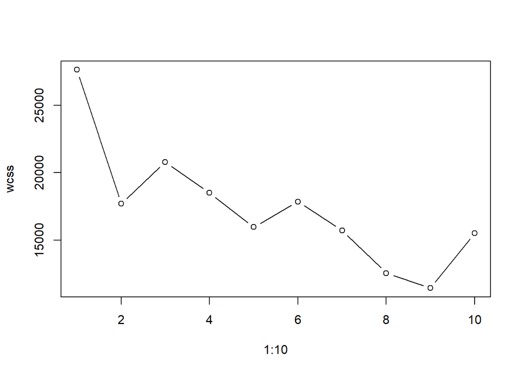

```r
set.seed(3)
wcss <- vector()
for (i in 1:10) wcss[i] = sum(kmeans(DATA_SET[,c(9,43:50)], i)$withinss)
plot(1:10, wcss, type = "b")
```

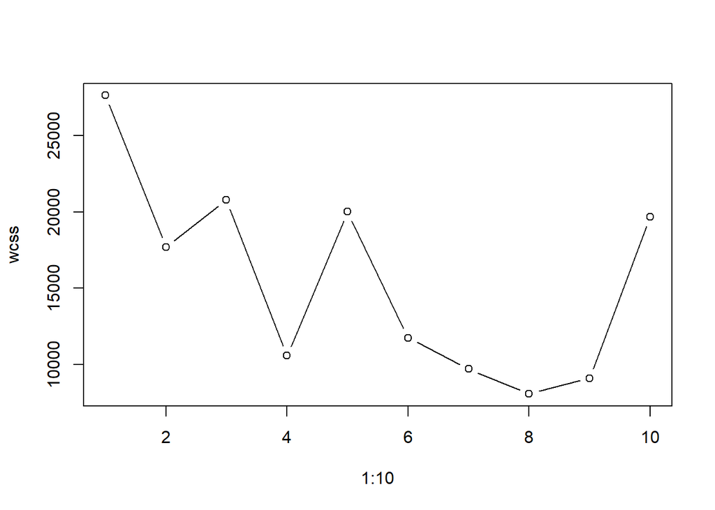

```r
set.seed(43)
wcss <- vector()
for (i in 1:10) wcss[i] = sum(kmeans(DATA_SET[,c(9,43:50)], i)$withinss)
plot(1:10, wcss, type = "b")
```

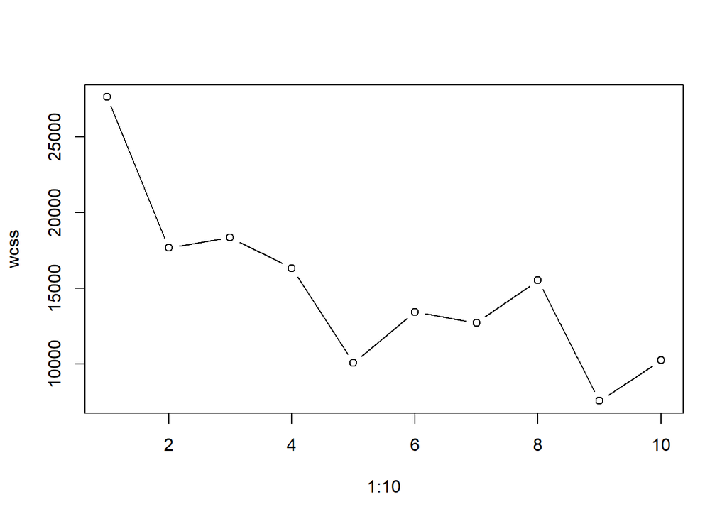

```r
set.seed(28)
wcss <- vector()
for (i in 1:10) wcss[i] = sum(kmeans(DATA_SET[,c(9,43:50)], i)$withinss)
plot(1:10, wcss, type = "b")
```

```r
set.seed(3)
kmeans(DATA_SET[,c(9,43:50)], 4)$centers
```

```
##         y   prev_cont p_success     prev_1      prev_2     prev_3_  camp_2_3
## 1 0.00000 0.001307474         0 0.06907823 0.006973197 0.002832861 0.0000000
## 2 0.65405 1.000000000         1 0.63285390 0.230885693 0.136260409 0.3981832
## 3 0.00000 0.002015197         0 0.09352494 0.009283119 0.002114305 0.4450611
## 4 1.00000 0.018768976         0 0.11813414 0.028705493 0.011040574 0.3825559
##    camp_4_6    camp_7_
## 1 1.0000000 0.00000000
## 2 0.0658592 0.00984103
## 3 0.0000000 0.07248100
## 4 0.1081976 0.02870549
```

```r
kmeans(DATA_SET[,c(9,43:50)], 9)$centers
```

```
##            y prev_cont p_success     prev_1      prev_2     prev_3_  camp_2_3
## 1 0.11965812 0.1168091 0.0000000 0.00000000 1.000000000 0.000000000 0.3276353
## 2 0.09407094 0.0000000 0.0000000 0.00000000 0.000000000 0.001641080 0.0000000
## 3 0.70711297 0.9790795 0.7531381 0.00000000 0.000000000 1.000000000 0.3933054
## 4 0.60047847 1.0000000 1.0000000 1.00000000 0.000000000 0.000000000 0.3935407
## 5 0.77101449 1.0000000 0.8840580 0.00000000 1.000000000 0.000000000 0.4000000
## 6 0.00000000 0.0000000 0.0000000 0.08998277 0.000000000 0.001648310 1.0000000
## 7 0.04323144 0.0000000 0.0000000 0.03231441 0.001746725 0.000000000 0.0000000
## 8 0.12639925 0.0000000 0.0000000 1.00000000 0.000000000 0.000000000 0.0000000
## 9 1.00000000 0.0000000 0.0000000 0.11535636 0.016164585 0.003673769 1.0000000
##     camp_4_6     camp_7_
## 1 0.10541311 0.008547009
## 2 0.24219164 0.000000000
## 3 0.05857741 0.008368201
## 4 0.06937799 0.008373206
## 5 0.06666667 0.011594203
## 6 0.00000000 0.000000000
## 7 0.00000000 1.000000000
## 8 0.16837687 0.002332090
## 9 0.00000000 0.000000000
```

```r
kmeans(DATA_SET[,c(9,43:50)], 9)$size
```

```
## [1]   836 21004  2150 13418  1358   208   361    82   386
```

```r
set.seed(43)
kmeans(DATA_SET[,c(9,43:50)], 5)$centers
```

```
##            y   prev_cont   p_success     prev_1      prev_2      prev_3_
## 1 1.00000000 0.233291615 0.216270338 0.22052566 0.081351690 0.0435544431
## 2 0.00000000 0.017127444 0.015239380 0.11672286 0.012879299 0.0034389751
## 3 0.00000000 0.015165946 0.012967983 0.09678365 0.010989816 0.0039563338
## 4 0.07729084 0.009760956 0.008565737 0.07828685 0.009362550 0.0031872510
## 5 0.04504114 0.006063231 0.004763967 0.03724556 0.003897791 0.0008661758
##    camp_2_3   camp_4_6      camp_7_
## 1 0.4342929 0.01201502 0.0005006258
## 2 0.0000000 0.00000000 0.0000000000
## 3 1.0000000 0.00000000 0.0000000000
## 4 0.0000000 1.00000000 0.0000000000
## 5 0.0000000 0.00000000 1.0000000000
```

```r
set.seed(28)
kmeans(DATA_SET[,c(9,43:50)], 4)$centers
```

```
##            y   prev_cont p_success    prev_1      prev_2     prev_3_  camp_2_3
## 1 0.11968680 0.000000000 0.0000000 1.0000000 0.000000000 0.000000000 0.3797539
## 2 0.67003610 1.000000000 0.9537906 0.6036101 0.246931408 0.149458484 0.3978339
## 3 0.09208524 0.002018397 0.0000000 0.0000000 0.011250083 0.002448547 0.4458672
## 4 0.07532468 0.002164502 0.0000000 0.0000000 0.008658009 0.003463203 0.0000000
##     camp_4_6     camp_7_
## 1 0.10095078 0.022091723
## 2 0.06281588 0.009386282
## 3 0.00000000 0.073423334
## 4 1.00000000 0.000000000
```

Similarly as above, curves are very sensitive to seed selection, but there is a visible tendency that clients not contacted before are far less likely to accept the offer when targeted. However, as mentioned before, it may be due to the fact that bank decides to contact clients that have higher probability of success - they do not subscribe because they have subscribed previously, but they are contacted in several campaigns, because they have responded positively in the previous campaigns.

## Models

In this part we will develop 3 classification models in order to precisely assess impact of particular variables in the data set on the target variable. Before we start modeling, we have to divide data set into training set and validation set. However, we can observe that the data is not well balanced:

```r
table(DATA_SET$y)
```

```
##
##     0     1
## 35316  4487
```

```r
sum(DATA_SET$y == 0) / sum(DATA_SET$y == 1)
```

```
## [1] 7.870738
```

Therefore, when assessing the models (while comparing models or tuning hyperparameters) or choosing the optimal cut-off, we will evaluate cost-based performance with a cost-matrix assigning weights according to the ratio of appearances of each value in the data:

```r
#Cost-based approach to assessing the model
CalculateCost = function(cut.off, cost.matrix, score, true.y){
  prediction = ifelse(score > cut.off, 1, 0)
  confusion.matrix = prop.table(table(true.y,
                                      factor(prediction, levels = c(0, 1))))
  return(sum(cost.matrix * confusion.matrix))
}
COST_MATRIX = matrix(c(0, 7.87, 1, 0), 2)
```

Split the data into training set and validation set:

```r
set.seed(1)
rand = sample(1:nrow(DATA_SET), 0.85 * nrow(DATA_SET))
train = DATA_SET[rand,]
val = DATA_SET[-rand,]
```

#### Logistic Regression

First modeling approach that we will take is Logistic Regression. We will use Bayesian Information Criterion to select explanatory variables and then tune optimal cut-off based on cost-based performance.

```r
full.logit = glm(y ~ ., data = train, family = binomial)
full.logit
```

```
##
## Call:  glm(formula = y ~ ., family = binomial, data = train)
##
## Coefficients:
##         (Intercept)                  age              housing
##          -2.343e+02           -3.054e-03            2.112e-02
##                loan         emp.var.rate       cons.price.idx
##          -3.640e-02           -1.541e+00            2.121e+00
##       cons.conf.idx            euribor3m          nr.employed
##           2.982e-02            2.486e-01            6.682e-03
##           housemaid             services               admin.
##          -9.322e-02           -2.451e-01           -6.755e-02
##         blue_collar           technician              retired
##          -2.609e-01           -9.533e-02            2.959e-01
##          management        self_employed         entrepreneur
##          -7.866e-02           -1.762e-01           -2.067e-01
##             student              married             divorced
##           4.978e-02           -6.034e-02           -1.137e-01
##            basic.4y          high.school             basic.6y
##          -1.170e-01           -5.226e-02           -6.397e-03
##            basic.9y  professional.course           illiterate
##          -1.626e-01           -5.586e-02            7.919e-01
##           telephone                  may                  jun
##          -7.727e-01           -6.312e-01           -9.093e-01
##                 jul                  aug                  oct
##          -1.972e-01            1.737e-01           -1.779e-01
##                 nov                  dec                  mar
##          -6.461e-01            6.501e-02            1.315e+00
##                 apr                  sep                  tue
##          -2.152e-01                   NA            2.938e-01
##                 wed                  thu                  fri
##           4.067e-01            2.958e-01            2.000e-01
##           prev_cont            p_success               prev_1
##           1.030e+00            8.903e-01           -5.282e-01
##              prev_2              prev_3_             camp_2_3
##          -5.826e-01           -6.648e-01           -1.434e-02
##            camp_4_6              camp_7_
##          -5.536e-02           -4.042e-01
##
## Degrees of Freedom: 33831 Total (i.e. Null);  33783 Residual
## Null Deviance:       23780
## Residual Deviance: 18640     AIC: 18740
```

```r
BIC.logit = step(full.logit, k = log(nrow(train)), trace = 0)
BIC.logit
```

```
##
## Call:  glm(formula = y ~ emp.var.rate + cons.price.idx + cons.conf.idx +
##     nr.employed + blue_collar + telephone + may + jun + jul +
##     nov + mar + apr + tue + wed + thu + prev_cont + p_success +
##     prev_1 + prev_2 + prev_3_ + camp_7_, family = binomial, data = train)
##
## Coefficients:
##    (Intercept)    emp.var.rate  cons.price.idx   cons.conf.idx     nr.employed
##     -262.31469        -1.46840         2.23683         0.04137         0.01027
##    blue_collar       telephone             may             jun             jul
##       -0.24857        -0.77516        -0.77893        -1.05650        -0.32535
##            nov             mar             apr             tue             wed
##       -0.67292         1.25039        -0.36749         0.20629         0.31943
##            thu       prev_cont       p_success          prev_1          prev_2
##        0.19827         1.04896         0.88129        -0.54576        -0.59115
##        prev_3_         camp_7_
##       -0.65854        -0.38151
##
## Degrees of Freedom: 33831 Total (i.e. Null);  33810 Residual
## Null Deviance:       23780
## Residual Deviance: 18700     AIC: 18750
```

A lot of variables concerning macroeconomic situation or information on previous contacts. Variables in those two groups are highly correlated with each other. Let’s check Variance Inflation Factor then:

```r
vif(BIC.logit)
```

```
##   emp.var.rate cons.price.idx  cons.conf.idx    nr.employed    blue_collar
##     122.779175      46.296795       2.578429      65.253978       1.054290
##      telephone            may            jun            jul            nov
##       2.394294       2.965109       7.022536       3.329585       2.004846
##            mar            apr            tue            wed            thu
##       1.353080       3.072191       1.246081       1.250028       1.249686
##      prev_cont      p_success         prev_1         prev_2        prev_3_
##      10.875811       9.445431       1.460540       1.463438       1.449874
##        camp_7_
##       1.018658
```

VIF values for emp.var.rate, cons.price.idx and nr.employed, as well as for prev_cont and p_success are unacceptably high. This implies collinearity. We can either drop some of these values from the model or reduce dimensionality, which is associated with further data preprocessing. Nonetheless, let’s move back and perform Principal Component Analysis.

First, let’s try to create one macroeconomic variable indicating stage of the business cycle:

```r
pca_macro <- preProcess(x = DATA_SET[,4:8], method = 'pca', pcaComp = 1)
pca_macro$rotation
```

```
##   emp.var.rate cons.price.idx  cons.conf.idx      euribor3m    nr.employed
##     -0.5315355     -0.4210421     -0.1338169     -0.5294815     -0.4918698
```

```r
pca_macro_pred <- predict(pca_macro, DATA_SET[,4:8])
cor(pca_macro_pred, DATA_SET[,4:9])
```

```
##     emp.var.rate cons.price.idx cons.conf.idx euribor3m nr.employed        y
## PC1   -0.9904022     -0.7845215    -0.2493391 -0.986575  -0.9164937 0.291565
```

Reduced PCA component is low when there is high variability on labor market, prices are high, consumers have quite positive attitude, short-term interest rates are high and unemployment is low. Thus, it is low at the peak of economic boom, at the verge of the collapse. This component is positively correlated with target variable, which is consistent with our previous considerations.

Now let’s deal with variables concerning previous contacts and campaigns. This time let’s create 2 components, as effects of contacts in previous campaigns and during current campaign may differ.

```r
pca_prev <- preProcess(x = DATA_SET[,43:50], method = 'pca', pcaComp = 2)
pca_prev$rotation
```

```
##                   PC1         PC2
## prev_cont  0.62747212 -0.04143745
## p_success  0.61332394 -0.03824141
## prev_1     0.25664692  0.04148155
## prev_2     0.28739703 -0.03522932
## prev_3_    0.27587060 -0.03471454
## camp_2_3   0.02201628  0.73957538
## camp_4_6  -0.04504443 -0.61224003
## camp_7_   -0.05504067 -0.26616539
```

```r
pca_prev_pred <- predict(pca_prev, DATA_SET[,43:50])
cor(pca_prev_pred, DATA_SET[,c(9,43:50)])
```

```
##               y   prev_cont   p_success     prev_1      prev_2     prev_3_
## PC1 0.330988169  0.96616690  0.94438185 0.39517893  0.44252723  0.42477910
## PC2 0.002588208 -0.04762827 -0.04395475 0.04767897 -0.04049264 -0.03990095
##       camp_2_3    camp_4_6     camp_7_
## PC1 0.03390016 -0.06935837 -0.08475033
## PC2 0.85006923 -0.70370976 -0.30593097
```

It seems that these components can be interpreted as follows: PC1 - responsible for previous campaigns and succeeding during them, PC2 - responsible for current campaign and number of contacts. PC1 is correlated with target value.